# Introdução à economia

Aula 19 - Mensurando o custo de vida

Prof. Roberto de Freitas Neder

## Aula 19: roteiro

**Mensurando o custo de vida** · Mankiw, capítulo 24 · UnB

- Construção dos índices
- Limites da mensuração
- Poder de compra e juros
- Conclusão
- Exercícios de concursos públicos

Use as setas para trocar de slide. Nas páginas longas, role o conteúdo. As respostas das atividades ficam fechadas até o clique.

## 01 - Quanto a renda permite comprar?

Um salário pode aumentar em reais e, ao mesmo tempo, comprar menos bens e serviços. Para comparar rendas e despesas ao longo do tempo, precisamos considerar a mudança dos preços.

O capítulo apresenta o **índice de preços ao consumidor**, suas limitações e o uso dos índices para corrigir valores monetários e taxas de juros.

Os exemplos numéricos desta aula são didáticos. A lógica do CPI norte-americano será relacionada aos indicadores brasileiros, sem confundir suas populações e metodologias.

**Base:** Mankiw, capítulo 24, *Measuring the Cost of Living*, pp. 495 a 512. PDF: pp. 524 a 541.

← Menu

## 02 - Nível de preços e inflação

Um índice de preços representa o custo relativo de um conjunto de produtos. A **inflação** é a variação percentual desse índice entre dois períodos.

$$\pi_t=\left(\frac{P_t}{P_{t-1}}-1\right)100$$

Se o índice passa de 100 para 110, a inflação é 10%. Se depois passa para 115,5, a inflação cai para 5%, embora os preços continuem aumentando.

**Desinflação:** redução da taxa de inflação. **Deflação:** queda do nível geral de preços. Um produto isolado ficar mais barato não basta para caracterizar deflação.

← Menu

## 03 - A cesta do consumidor

O índice do exemplo mantém uma cesta de quantidades fixa para comparar quanto custa comprá-la em diferentes anos.

Os pesos devem representar o orçamento da população de referência. Um produto com grande participação no gasto exerce mais influência do que um item pouco consumido.

Uma cesta média não reproduz exatamente a cesta de cada família. Renda, idade, região, composição familiar e necessidades de saúde alteram a distribuição dos gastos.

**Medir inflação exige definir de quem é o consumo que estamos acompanhando.**

← Menu

## 04 - Cinco etapas do cálculo

1. Definir as quantidades da cesta de referência.
2. Observar os preços em cada período.
3. Calcular o custo dessa mesma cesta a cada conjunto de preços.
4. Escolher o período-base e expressar os custos relativamente a ele.
5. Calcular a variação percentual do índice.

$$IPC_t=\frac{\sum_i p_{i,t}q_{i,0}}{\sum_i p_{i,0}q_{i,0}}\times100$$

Essa fórmula de cesta fixa é uma introdução ao índice de Laspeyres. Os índices oficiais utilizam procedimentos de amostragem, atualização e agregação mais detalhados.

← Menu

## 05 - Exemplo: o custo da mesma cesta

**Cesta didática:** 10 unidades de alimento e 4 viagens.

| Produto | Quantidade fixa | Preço A | Preço B | Preço C |
| --- | --- | --- | --- | --- |
| Alimento | 10 | 10 | 12 | 13 |
| Viagem | 4 | 5 | 6 | 7 |
| Custo da cesta |  | **120** | **144** | **158** |

O custo de B é $10(12)+4(6)=144$. Em C, $10(13)+4(7)=158$.

Mantemos as quantidades para que a diferença dos custos reflita apenas a mudança dos preços considerados.

← Menu

## 06 - Índice e inflação no exemplo

Com A como base:

| Ano | Custo da cesta | IPC | Inflação em relação ao ano anterior |
| --- | --- | --- | --- |
| A | 120 | 100 | Não calculada |
| B | 144 | 120 | 20% |
| C | 158 | 131,67 | 9,72% |

$$\pi_C=\left(\frac{158}{144}-1\right)100\approx9{,}72\%$$

A diferença de 11,67 **pontos do índice** entre B e C não é a taxa de inflação. A base da variação é o valor de B, igual a 120.

← Menu

## 07 - Acumulação e mudança de base

Inflações sucessivas se acumulam multiplicativamente:

$$1+\pi_{acumulada}=\prod_t(1+\pi_t)$$

Duas altas de 10% geram $1{,}10^2-1=21\%$, não 20%. No exemplo da cesta, 20% seguidos de 9,72% resultam em aproximadamente 31,67%.

Mudar o ano-base apenas reescala o índice, se a série permanecer a mesma. Não altera as taxas de variação entre datas.

**Exemplo:** os índices 100 e 120 podem ser reexpressos como 83,33 e 100. A alta continua sendo de 20%.

← Menu

## 08 - Pesos diferentes, experiências diferentes

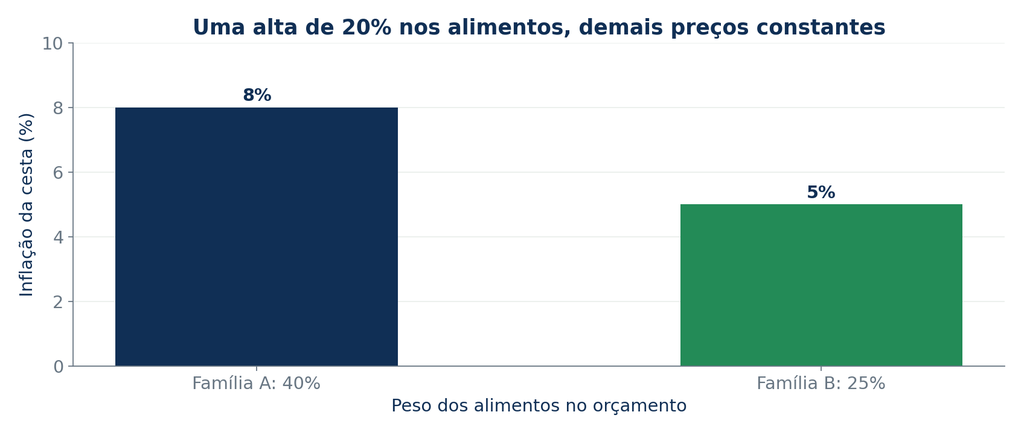

Duas famílias hipotéticas com diferentes participações de alimentação e demais despesas enfrentam inflação de 8% e 5%, respectivamente.

Fonte: elaboração didática. Dados hipotéticos, salvo indicação expressa.

**Exemplo:** alimentos sobem 20% e os demais preços ficam constantes. Com alimentos representando 40% do gasto-base, a alta da cesta é 8%. Com peso de 25%, é 5%.

Um índice médio pode estar correto e divergir da experiência particular de uma família.

← Menu

## 09 - IPCA, INPC e outros indicadores

No Brasil, o IBGE produz IPCA e INPC. Eles diferem, entre outros aspectos, pela população de referência e, portanto, pela estrutura de ponderação.

O IPCA acompanha uma faixa de renda mais ampla. O INPC concentra-se em famílias de renda mais baixa com características específicas de inserção no trabalho. Consulte sempre a metodologia vigente.

Índices ao produtor e índices gerais acompanham universos diferentes. Não são substitutos automáticos de um índice de preços ao consumidor.

[IBGE: inflação e índices](https://www.ibge.gov.br/explica/inflacao.php)

← Menu

## 10 - Jogo rápido: preços estão caindo?

1. A inflação anual caiu de 8% para 4%. Os preços, em média, voltaram ao nível anterior?
2. Um índice passou de 200 para 210. A inflação foi 10%?
3. Um preço subiu 20% e depois caiu 20%. Voltou ao ponto inicial?

**Conferir respostas**

1. Não. Houve desinflação, com preços ainda aumentando. 2. Não. A alta foi $10/200=5\%$. 3. Não. $1{,}20\times0{,}80=0{,}96$, ficando 4% abaixo do valor inicial.

← Menu

## 11 - Custo de uma cesta e custo de vida

O custo de vida está relacionado ao gasto necessário para manter um nível de bem-estar. O custo de uma cesta fixa acompanha os mesmos produtos e quantidades.

Essas duas medidas podem divergir porque consumidores substituem produtos, novos bens surgem e a qualidade muda.

O capítulo destaca três dificuldades: **viés de substituição**, **introdução de novos bens** e **mudanças de qualidade**.

Os institutos de estatística ajustam suas metodologias para enfrentar esses problemas. Identificá-los não implica afirmar que os índices sejam arbitrários ou inúteis.

← Menu

## 12 - Substituição entre produtos

Se o preço da carne bovina aumenta muito e o do frango fica estável, uma família pode substituir parte do consumo. Uma cesta fixa preserva a quantidade original de carne bovina.

Assim, ela pode indicar um aumento do gasto maior do que o necessário para manter o bem-estar mediante substituição.

Esse **viés de substituição** depende das possibilidades reais de ajuste. Necessidades médicas, restrições alimentares e falta de alternativas podem limitar a substituição.

O consumidor trocar de produto não significa que a alta de preço deixou de prejudicá-lo.

← Menu

## 13 - Um exemplo da substituição

Considere dois alimentos que, apenas neste exemplo, são substitutos perfeitos para o consumidor. Inicialmente, ambos custam R$ 10, e ele compra duas unidades de cada um.

Um deles passa a R$ 20 e o outro permanece em R$ 10. A cesta fixa passa de R$ 40 para R$ 60, alta de 50%.

Se quatro unidades do alimento mais barato preservam exatamente a satisfação, o consumidor continua precisando de R$ 40.

A hipótese forte de substituição perfeita torna o mecanismo visível. **Não se pode presumir que qualquer troca preserve a mesma qualidade de vida.**

← Menu

## 14 - Novos bens e ampliação de opções

O aparecimento de um produto pode permitir que uma família alcance determinada satisfação com menor gasto ou tenha acesso a possibilidades antes inexistentes.

Uma cesta antiga não registra imediatamente todo esse ganho. A comparação fica especialmente difícil quando não existe produto equivalente no período anterior.

O capítulo usa inovações e mudanças tecnológicas para mostrar que observar somente o preço de produtos já existentes pode perder parte da mudança do custo de vida.

Maior variedade gera benefícios potenciais, mas sua valoração exige hipóteses e evidência sobre escolhas dos consumidores.

← Menu

## 15 - Mudanças de qualidade

Um computador novo pode custar o mesmo e oferecer maior capacidade. Um serviço pode manter o preço, mas reduzir cobertura ou atendimento.

Comparar apenas os valores monetários trataria produtos diferentes como se fossem idênticos. O desafio é separar a mudança de preço da mudança de qualidade.

Ajustes por características e substituição de produtos nas amostras procuram lidar com isso. Nenhum método observa diretamente toda a utilidade que cada pessoa obtém.

**Reduzir a quantidade da embalagem, mantendo o preço, também pode representar aumento do preço por unidade.**

← Menu

## 16 - Preços na internet e cobertura

O capítulo discute o uso de preços disponíveis na internet. A coleta frequente permite observar mudanças rapidamente e acompanhar grande quantidade de produtos.

Entretanto, preços anunciados podem diferir dos efetivamente pagos. Frete, descontos personalizados, disponibilidade e mudança de composição dos vendedores afetam a comparação.

Serviços locais e compras presenciais também podem ficar pouco representados.

A quantidade de observações não elimina o problema de definir uma amostra representativa e acompanhar produtos comparáveis ao longo do tempo.

← Menu

## 17 - IPC e deflator do PIB

| Aspecto | IPC de cesta fixa | Deflator do PIB |
| --- | --- | --- |
| Universo | Consumo da população de referência | Produção final doméstica |
| Importados | Podem entrar na cesta | Não entram diretamente como produção interna |
| Exportados | Em geral não fazem parte da cesta familiar | Entram na produção doméstica |
| Capital e serviços públicos | Cobertura depende do consumo familiar | Integram o conjunto produzido |
| Quantidades | Fixas no exemplo introdutório | Ligadas à composição da produção |

As medidas respondem a perguntas distintas. Por isso, podem apresentar taxas diferentes sem que uma esteja necessariamente errada.

← Menu

## 18 - Dois choques de preços

**Combustível importado consumido pelas famílias fica mais caro:** pode pressionar diretamente o IPC. Não entra diretamente no deflator como produção doméstica, embora existam efeitos indiretos sobre custos e preços internos.

**Uma máquina doméstica destinada à exportação fica mais cara:** afeta o deflator, mas não precisa afetar diretamente a cesta de consumo.

Para explicar a diferença entre índices, observe **quais produtos entram e quais pesos recebem**. Dizer apenas que ambos “medem inflação” não resolve a comparação.

← Menu

## 19 - Valores de épocas diferentes

Para expressar uma quantia antiga em preços de uma data de referência:

$$V_{referencia}=V_{antigo}\frac{P_{referencia}}{P_{antigo}}$$

**Exemplo didático:** uma renda de R$ 2.000 quando o índice era 100 equivale a R$ 3.000 quando o índice é 150.

Isso não informa quanto a pessoa efetivamente recebeu na nova data. Informa a quantia necessária para preservar o poder de compra segundo o índice escolhido.

O índice deve corresponder à pergunta. Um deflator de investimento não substitui automaticamente um índice de consumo familiar.

← Menu

## 20 - Salário nominal e salário real

Uma renda nominal passa de R$ 2.000 para R$ 2.200, alta de 10%. No mesmo período, a inflação é 15%.

$$g_{real}=\frac{1{,}10}{1{,}15}-1\approx-4{,}35\%$$

Em preços do período inicial, o salário final equivale a $2.200/1{,}15\approx R\$\ 1.913{,}04$.

O trabalhador recebeu mais reais, mas o poder de compra caiu. A diferença de 10% menos 15%, igual a -5%, é apenas uma aproximação.

Comparações regionais exigem outro cuidado: preços distintos entre lugares também alteram o poder de compra de uma renda igual.

← Menu

## 21 - Indexação

Indexar um valor é prever sua atualização por um índice, por lei ou contrato. Podem ser indexados salários, benefícios, aluguéis e parcelas de contratos.

A indexação pode proteger poder de compra, mas é preciso observar qual índice se aplica, o intervalo de correção e se o reajuste é integral.

Uma correção anual não impede perda de poder de compra dentro do ano. Além disso, a cesta da pessoa pode divergir da cesta do índice.

O capítulo mostra também que regras tributárias nominais podem alterar a carga real quando não acompanham os preços.

← Menu

## 22 - Juros nominais e reais

A taxa **nominal** informa o crescimento do valor em dinheiro. A taxa **real** informa quanto cresce a capacidade de comprar bens e serviços.

$$1+r=\frac{1+i}{1+\pi}$$
$$r=\frac{i-\pi}{1+\pi}\qquad\text{e, aproximadamente,}\qquad r\approx i-\pi$$

Na fórmula, use taxas em forma decimal. A aproximação funciona melhor com taxas baixas.

O retorno real depende da inflação no mesmo período da taxa de juros. Não compare juros mensais com inflação anual sem converter os intervalos.

← Menu

## 23 - Aplicação: o ganho que sobra

Uma aplicação didática de R$ 1.000 paga 10% em um ano, sem impostos ou taxas. O saldo final é R$ 1.100.

Com inflação de 6%, o saldo equivale a $1.100/1{,}06\approx R\$\ 1.037{,}74$ em poder de compra inicial.

$$r=\frac{1{,}10}{1{,}06}-1\approx3{,}77\%$$

Se a inflação fosse 12%, o retorno real seria $1{,}10/1{,}12-1\approx-1{,}79\%$.

O recebimento de juros nominais positivos pode coexistir com perda real.

← Menu

## 24 - Inflação esperada e realizada

No momento de contratar, a inflação futura é desconhecida. Credores e devedores avaliam uma taxa real **esperada**, a partir de uma previsão.

Depois, a inflação realizada permite calcular a taxa real efetiva. Se os preços sobem mais do que se esperava, o poder de compra do pagamento fixado em termos nominais fica menor.

Essa surpresa tende a beneficiar o devedor e prejudicar o credor em um contrato nominal simples. Contratos indexados, revisão de taxas e impostos podem alterar o resultado.

A relação de Fisher organiza a comparação, mas não elimina o risco inflacionário.

← Menu

## 25 - Jogo rápido: comparar corretamente

1. Uma renda cresce 8% e os preços 8%. Qual é a variação real?
2. Juros de 5% e inflação de 10% garantem aumento do poder de compra?
3. Por que uma lista de maiores bilheterias nominais pode favorecer filmes recentes?

**Conferir respostas**

1. Zero, pois $1{,}08/1{,}08=1$. 2. Não. O retorno real é $1{,}05/1{,}10-1\approx-4{,}55\%$. 3. Preços maiores dos ingressos elevam os valores nominais. Corrigir por preços e observar quantidade de ingressos ajuda a construir uma comparação adequada.

← Menu

## 26 - Conclusão: reais e poder de compra

Um índice de preços transforma mudanças de muitos produtos em uma medida agregada. Para interpretá-lo, precisamos conhecer sua cesta, seus pesos, sua população de referência e suas limitações.

**Inflação menor ainda pode significar preços maiores.** E um salário ou rendimento nominal maior pode representar perda real.

Deflacionar valores permite comparar poder de compra. A correção não substitui a análise da distribuição dos gastos nem resolve, sozinha, diferenças regionais e de qualidade.

Na aula seguinte, estudaremos por que a capacidade de produzir por pessoa muda ao longo do tempo.

← Menu

## Exercícios de concursos públicos

Oito exercícios selecionados. Nos itens de julgamento, use **C (certo/verdadeiro)** ou **E (errado/falso)**. Leia os enunciados antes de abrir as respostas. As fontes e as adaptações estão identificadas em cada questão.

### Questão 01

FGV, ALE/GO, Analista Legislativo, Economista, 2026, tipo 1 · questão 63

IPC com cesta-base A=2 e B=3. Preços-base: 10 e 20; preços novos: 12 e 25. Qual a inflação?

1. 12,50%
2. 15,00%
3. 21,25%
4. 23,75%
5. 24,44%

Redação sintetizada para uso didático; dados e resposta preservados.

[Prova original](https://conhecimento.fgv.br/sites/default/files/concursos/analista-legislativo-economista-cns207-tipo-1.pdf) · [Gabarito oficial](https://conhecimento.fgv.br/sites/default/files/concursos/gabarito-definitivo-ale-go.pdf)

Resposta comentada

### Questão 02

FGV, ALE/AM, Analista Legislativo, Economista, 2025, tipo 1 · questão 68

Qual afirmação descreve corretamente o IPCA?

1. Índice de atacado
2. Inflação de um só produto
3. Deflator tem cesta fixa
4. Índice do IBGE usado nas metas
5. Trimestral, renda de 1 a 5 mínimos

Redação sintetizada para uso didático; dados e resposta preservados.

[Prova original](https://conhecimento.fgv.br/sites/default/files/concursos/analista-legislativo-economista-cns309-tipo-1.pdf) · [Gabarito oficial](https://conhecimento.fgv.br/sites/default/files/concursos/gabarito-definitivo-ale-am.pdf)

Resposta comentada

### Questão 03

FGV, ALE/PR, Analista Legislativo, Economista, 2024, tipo 1 · questão 62

Aplicação: +20% nominal e −20% real em um ano. Qual a inflação?

1. 0%
2. 40%
3. 20%
4. 10%
5. 50%

Redação sintetizada para uso didático; dados e resposta preservados.

[Prova original](https://conhecimento.fgv.br/sites/default/files/concursos/analista-legislativo-economistae2cns04-tipo-1.pdf) · [Gabarito oficial](https://conhecimento.fgv.br/sites/default/files/concursos/ale-pr-gabarito-definitivo-cargos-do-edital-2.pdf)

Resposta comentada

### Questão 04

CESPE, Senado Federal, Consultor Legislativo, Área 14, 2002 · questão 55, 4º item

Os aumentos dos preços dos produtos importados, quando geram redução do consumo dessas mercadorias, contribuem para aumentar o viés de substituição associado à mensuração dos índices de custo de vida.

**( ) C ( ) E**

Item original C/E, com normalização de espaçamento. A prova autoriza reprodução com indicação da fonte.

[Prova original](https://cdn.cebraspe.org.br/concursos/_antigos/2002/senado/Arquivos/area_14_LEGISL_1Et.pdf) · [Gabarito oficial](https://cdn.cebraspe.org.br/concursos/_antigos/2002/senado/Arquivos/Gab_Def-SENADO.pdf)

Resposta comentada

### Questão 05

Cebraspe, TCE/SC, Auditor Fiscal de Controle Externo, Economia, 2016 · questão 118

Terreno comprado por 40000 e vendido por 62400; inflação acumulada de 20%. O retorno real ultrapassou 32%.

**( ) C ( ) E**

Redação sintetizada para uso didático; dados e resposta preservados.

[Prova original](https://cdn.cebraspe.org.br/concursos/TCE_SC_15/arquivos/230TCESC_004_01.pdf) · [Gabarito oficial](https://cdn.cebraspe.org.br/concursos/TCE_SC_15/arquivos/Gab_Definitivo_230TCESC_004_01.pdf)

Resposta comentada

### Questão 06

FGV, ALE/PR, Analista Legislativo, Economista, 2024, tipo 1 · questão 45, afirmação I

Deflação significa recuo persistente e disseminado do nível de preços.

**( ) C ( ) E**

Afirmação I isolada e convertida para C/E; gabarito da questão completa: E, todas as afirmações corretas.

[Prova original](https://conhecimento.fgv.br/sites/default/files/concursos/analista-legislativo-economistae2cns04-tipo-1.pdf) · [Gabarito oficial](https://conhecimento.fgv.br/sites/default/files/concursos/ale-pr-gabarito-definitivo-cargos-do-edital-2.pdf)

Resposta comentada

### Questão 07

FGV, ALE/SC, Analista Legislativo III, Economista, 2024, tipo 1 · questão 46

Que mecanismo caracteriza inflação de custos?

1. Menor consumo aumenta demanda
2. Insumos mais caros pressionam preços finais
3. Emissão só produz inflação em crises
4. Contração fiscal equivale a inflação estrutural
5. Esperar deflação define inflação psicológica

Redação sintetizada para uso didático; dados e resposta preservados.

[Prova original](https://conhecimento.fgv.br/sites/default/files/concursos/analista-legislativo-iii-economistacns108-tipo-1.pdf) · [Gabarito oficial](https://conhecimento.fgv.br/sites/default/files/concursos/alesc2024_gabarito_definitivo.pdf)

Resposta comentada

### Questão 08

CESPE, Senado Federal, Consultor Legislativo, Área 14, 2002 · questão 55, 3º item

Considerando que o PIB nominal de 2000 foi superior ao PIB nominal verificado em 1999, é correto concluir que houve aumento da produção nesse período.

**( ) C ( ) E**

Item original C/E, com normalização de espaçamento. A prova autoriza reprodução com indicação da fonte.

[Prova original](https://cdn.cebraspe.org.br/concursos/_antigos/2002/senado/Arquivos/area_14_LEGISL_1Et.pdf) · [Gabarito oficial](https://cdn.cebraspe.org.br/concursos/_antigos/2002/senado/Arquivos/Gab_Def-SENADO.pdf)

Resposta comentada

**Gabarito resumido e resoluções comentadas**

| Questão | 01 | 02 | 03 | 04 | 05 | 06 | 07 | 08 |
| --- | --- | --- | --- | --- | --- | --- | --- | --- |
| Resposta | D | D | E | C | E | C | B | E |

**Questão 01: D**

Custo inicial: $2(10)+3(20)=80$. Custo novo da mesma cesta: $2(12)+3(25)=99$. A inflação é $(99/80-1)100=23{,}75\%$. Quantidades atuais não substituem as quantidades-base no cálculo de Laspeyres.

Voltar ao enunciado

**Questão 02: D**

O IBGE calcula o IPCA, índice de referência do regime brasileiro de metas de inflação. Ele mede preços ao consumidor; é mensal e não se confunde com o deflator do PIB.

Voltar ao enunciado

**Questão 03: E**

$1+r=(1+i)/(1+\pi)$. Assim, $0{,}8=1{,}2/(1+\pi)$ e $\pi=50\%$. Subtrair taxas daria uma aproximação inadequada para variações tão grandes.

Voltar ao enunciado

**Questão 04: C**

Se o consumidor substitui importados que ficaram relativamente caros por outros produtos, uma cesta fixa não acompanha plenamente a adaptação. Por isso pode superestimar o aumento do custo necessário para manter um dado nível de satisfação.

Voltar ao enunciado

**Questão 05: E**

O retorno nominal é $56\%$. O real é $1{,}56/1{,}20-1=30\%$, portanto inferior a 32%. Inflação acumulada deve corresponder ao mesmo intervalo da aplicação.

Voltar ao enunciado

**Questão 06: C**

A afirmação I foi considerada correta na alternativa E da questão original. Deflação não é apenas a queda do preço de uma mercadoria. Desinflação é redução da taxa de inflação, que pode continuar positiva.

Voltar ao enunciado

**Questão 07: B**

Um choque no preço de insumos relevantes pode aumentar custos e pressionar preços finais. Um índice de inflação mede o resultado, mas sozinho não identifica a causa do movimento.

Voltar ao enunciado

**Questão 08: E**

Uma série nominal não separa preço e volume. Um aumento de receita ou de produção medida em reais pode resultar apenas da inflação; o deflacionamento é necessário para comparação real.

Voltar ao enunciado

← Menu